# Multi-Environment GWAS with wgAim

Author

Julian Taylor & Ari Verbyla

Published

August 5, 2026

## 1 Overview

This vignette demonstrates the multi-environment extension of the **wgAim** GWAS pipeline for a diversity panel evaluated across several field trials. The framework detects markers whose effects are consistent across trials (**main-effect QTL**, MAIN) as well as markers whose effects differ between trials (**G×E interaction QTL**, INT), within a unified forward-selection model — exactly as the multivariate `qtlAim()` engine does for biparental crosses.

The pipeline has the same three stages as the univariate GWAS analysis:

1. **Pre-analysis** — check, filter and prime the diversity panel with `checkPanel()`, `filterPanel()` and `primePanel()`.
2. **Analysis** — develop a multi-trial base model and run `gwasAim()` with the `Trait` argument set to the grouping factor (here `"Site"`).
3. **Post-analysis** — interrogate, summarise, and visualise the detected markers using `summary()`, `plot()`, and `aimTrace()`.

The `Trait` argument is a general grouping factor: it may represent sites, trials, environments, seasons, or measured traits — any factor whose levels define the multivariate response. In this vignette `Trait = "Site"`.

Throughout we use the `genoGWASraw`, `mapGWASsim` and `phenoGWASsim` datasets bundled with the package. `genoGWASraw` and `mapGWASsim` represent a simulated diversity panel of 200 lines genotyped at approximately 1700 SNP markers across 10 chromosomes (~170 markers per chromosome, average spacing ~0.9 cM), evaluated in 6 field sites with 2 replicates each. The panel is generated with `AlphaSimR` with 50 founder haplotypes via a coalescent (`runMacs2`), one generation of random mating to produce 200 F1 diverse lines, then a SNP chip actively selected from segregating sites with minor allele frequency (MAF) > 0.15. All shipped markers have F1 MAF > 0.15 (median ~0.32), giving a kinship matrix $\boldsymbol{K}$ with genuine full-rank structure (off-diagonal SD ~0.085) that captures the half-sib / full-sib relatedness naturally. Yields are on the tonnes-per-hectare scale (site means 4.5–4.9 t/ha, residual SD ~0.377 t/ha per site) with two structured components matching the multivariate analysis’s `fa(Site,k):vm(id, K) + fa(Site,k):id` decomposition (both kept deliberately small so the composite LRT stops cleanly once true QTL are absorbed). Five QTL were planted at known positions to give ground truth for detection: three with consistent effects across all sites (Chr2 +0.145 t/ha, Chr5 −0.145 t/ha, and Chr7 +0.125 t/ha — the third being deliberately weak to sit near the detection threshold), and two with site-specific effects (Chr3 fading from +0.230 t/ha in `Env1` to 0 in `Env6`; Chr9 crossing from −0.180 t/ha in `Env1`–`Env3` to +0.180 t/ha in `Env4`–`Env6`). The raw marker matrix contains realistic data-quality issues (missingness, monomorphic markers, duplicate lines, duplicate markers, unplaceable markers) so the full pre-analysis pipeline can be exercised. See the roxygen help for `?phenoGWASsim` for the full specification.

**Requires:** ASReml-R V4. The vignette is pre-rendered so no licence is needed to read it. Run the code chunks only if you have ASReml-R installed.

## 2 Mathematical Framework

The mathematical framework underpinning multi-environment `gwasAim()` is essentially identical to that of multivariate `qtlAim()`. Please see the **Mathematical Framework** section of the Multivariate QTL Mapping vignette for the full algorithmic pipeline.

### 2.1 What’s different in GWAS

The same three GWAS-specific differences noted in the univariate GWAS vignette apply here:

1. **Marker matrix source.** `qtlAim()` uses virtual mid-interval scores from `primeCross(type = "interval")`. `gwasAim()` uses the *actual* panel markers assembled by `primePanel()`, coded $\pm 1$ after the $x \mapsto x - 1$ shift from raw $0/1/2$ counts (heterozygotes at $0$). Each panel marker is used directly.
2. **Population structure.** Diversity panels typically carry both short-range LD and long-range stratification from subpopulations; both are absorbed by the composite additive term via $\boldsymbol{G}_a \otimes \boldsymbol{K}$ in the vm path.
3. **The vm path dominates.** Panels almost always satisfy $p \gg n$, so the multivariate vm formulation $\boldsymbol{a} \sim \mathcal{N}(\boldsymbol{0},\, \boldsymbol{G}_a \otimes \boldsymbol{K})$ with $\boldsymbol{K} = \tfrac{1}{p}\boldsymbol{M}\boldsymbol{M}^{\top}$ is selected automatically.

## 3 Data Preparation

The pre-analysis pipeline is identical to the univariate GWAS vignette: `checkPanel()` for a diagnostic scan, `filterPanel()` for quality filtering with a principled step order, and `primePanel()` for $\pm 1$ recoding, chromosome-wise splitting and residual KNN imputation. See the Univariate GWAS vignette for detailed narrative on each function. Here we run all three in a single condensed block:

```r
data(genoGWASraw,  package = "wgAim")
data(mapGWASsim,   package = "wgAim")
data(phenoGWASsim, package = "wgAim")

chk   <- checkPanel(genoGWASraw, mapGWASsim, id = "id")
flt   <- filterPanel(chk)
panel <- primePanel(flt, impute = "knn", knn.k = 5)

cat(sprintf("Prepared panel : %d lines x %d markers across %d chromosomes\n",
            nrow(panel$pheno),
            sum(sapply(panel$geno, function(el) ncol(el$imputed.data))),
            length(panel$geno)))
```

```
Prepared panel : 191 lines x 1501 markers across 10 chromosomes
```

With ~191 lines and ~1500 markers after filtering, the panel sits firmly in the $p \gg n$ regime and `gwasAim()` will use the vm path automatically at every iteration of forward selection.

### 3.1 Phenotype setup

The phenotype is a balanced 6-site, 2-replicate MET with `Site`, `id` and `Rep` as factors. We use *all* 6 sites in the multi-environment analysis (the univariate GWAS vignette used only `Env1`). The site names are zero-padded to the minimum width needed — for 6 sites this gives `Env1`..`Env6`:

```r
pheno <- phenoGWASsim
pheno$id   <- factor(pheno$id)
n.sites    <- nlevels(pheno$Site)
site.width <- nchar(as.character(n.sites))
env.names  <- sprintf(paste0("Env%0", site.width, "d"), seq_len(n.sites))
pheno$Site <- factor(pheno$Site, levels = env.names)
pheno$Rep  <- factor(pheno$Rep)

cat(sprintf("Phenotype : %d rows across %d sites (%d lines x %d reps per site)\n",
            nrow(pheno), nlevels(pheno$Site),
            nlevels(pheno$id), nlevels(pheno$Rep)))
```

```
Phenotype : 2400 rows across 6 sites (200 lines x 2 reps per site)
```

## 4 Base Model Development

The starting point for a multi-environment `gwasAim()` analysis is a converged multi-trial base model that captures the experimental design structure and the genetic (co)variance across sites. We build this incrementally, comparing three variance structures for the genetic term.

### 4.1 Step 1 — Diagonal structure

The simplest multi-site model assumes genetic effects in each site are **independent**: $\boldsymbol{G}_a = \text{diag}(\sigma^2_{g,1}, \ldots, \sigma^2_{g,T})$ with no between-site genetic correlations.

```r
base_diag <- asreml(
  fixed     = yield ~ Site + Site:Rep,
  random    = ~ diag(Site):id,
  residual  = ~ dsum(~units | Site),
  data      = pheno,
  na.action = na.method(x = "include"),
  maxit     = 100
)
base_diag <- update(base_diag)
```

### 4.2 Step 2 — Factor analytic order 1

A single-factor model FA(1) introduces one set of loadings and captures the dominant axis of genotype-by-site interaction:

```r
base_fa1 <- asreml(
  fixed     = yield ~ Site + Site:Rep,
  random    = ~ fa(Site, 1):id,
  residual  = ~ dsum(~units | Site),
  data      = pheno,
  na.action = na.method(x = "include"),
  maxit     = 100
)
base_fa1 <- update(base_fa1)
```

### 4.3 Step 3 — Factor analytic order 2

A two-factor model FA(2) captures two axes of interaction and provides a richer description of the genetic covariance. This is the model we carry into `gwasAim()`:

```r
base_fa2 <- asreml(
  fixed     = yield ~ Site + Site:Rep,
  random    = ~ fa(Site, 2):id,
  residual  = ~ dsum(~units | Site),
  data      = pheno,
  na.action = na.method(x = "include"),
  maxit     = 100
)
base_fa2 <- update(base_fa2)
```

### 4.4 Model comparison

We compare the three variance structures using their restricted log-likelihoods and an AIC-style penalty. Parameter counts for `n.sites` = 6 sites are: `diag` = 6 (variance per site); `fa1` = 6 psi + 6 loadings = 12; `fa2` = 6 psi + 12 loadings = 18. Each model also carries the 6 residual variances from `dsum(~units | Site)`:

```r
np <- c(diag = as.integer(   n.sites + n.sites),
        fa1  = as.integer(2L*n.sites + n.sites),
        fa2  = as.integer(3L*n.sites + n.sites))
comp <- data.frame(
  Model      = c("diag(Site):id", "fa(Site, 1):id", "fa(Site, 2):id"),
  Parameters = np,
  LogLik     = round(c(base_diag$loglik, base_fa1$loglik, base_fa2$loglik), 2),
  AIC        = round(c(-2*base_diag$loglik + 2*np["diag"],
                        -2*base_fa1$loglik  + 2*np["fa1"],
                        -2*base_fa2$loglik  + 2*np["fa2"]),   2),
  stringsAsFactors = FALSE
)
print(comp, row.names = FALSE)
```

```
          Model Parameters LogLik      AIC
  diag(Site):id         12 622.06 -1220.12
 fa(Site, 1):id         18 709.10 -1382.20
 fa(Site, 2):id         24 734.17 -1420.34
```

FA(2) provides the best balance between fit and parsimony while capturing two axes of genotype-by-site interaction across the six sites.

## 5 GWAS Mapping — `gwasAim()`

### 5.1 Running `gwasAim()`

The `Trait` argument activates the multivariate engine, treating `"Site"` as the grouping factor. Leaving `str = NULL` (the default) instructs `gwasAim()` to **mirror** the variance structure of the base model — here FA(2) — for the composite genome-wide random term, giving consistent modelling of the genetic covariance at every iteration without needing to respecify the order.

We use the default significance level `TypeI = 0.05`, applied at the family-wise level (the single omnibus multivariate LRT per iteration does not need Bonferroni correction — see the referenced Mathematical Framework section for the argument):

```r
gwas_mv <- gwasAim(
  baseModel        = base_fa2,
  genObj           = panel,
  merge.by         = "id",
  Trait            = "Site",
  str              = NULL,            # mirror the FA(2) structure
  exclusion.window = 20,
  TypeI            = 0.05,
  trace            = FALSE,
  na.action        = na.method(x = "include"),
  maxit            = 100
)
```

```r
cat("Class              :", paste(class(gwas_mv), collapse = ", "), "\n")
```

```
Class              : gwasAim, asreml
```

```r
cat("Trait              :", gwas_mv$QTL$Trait, "\n")
```

```
Trait              : Site
```

```r
cat("Markers in panel   :", gwas_mv$QTL$n.markers, "\n")
```

```
Markers in panel   : 1501
```

```r
cat("Significant markers:", length(gwas_mv$QTL$qtl), "\n")
```

```
Significant markers: 5
```

## 6 Results

### 6.1 `print()` — brief narrative

`print()` reports the significance threshold, panel size and one line per detected marker with its chromosome, name and cM position, plus a `[MAIN]` or `[INTERACTION]` tag from the post-selection Wald pruning:

```r
print(gwas_mv, genObj = panel)
```

```
GWAS forward selection  TypeI = 0.0500  (1501 markers in panel)

Significant marker on chromosome Chr9: SNP_C09_0068 (60.72 cM) [INTERACTION]

Significant marker on chromosome Chr3: SNP_C03_0128 (110.03 cM) [INTERACTION]

Significant marker on chromosome Chr5: SNP_C05_0094 (90.47 cM) [MAIN]

Significant marker on chromosome Chr2: SNP_C02_0044 (46.00 cM) [MAIN]

Significant marker on chromosome Chr7: SNP_C07_0042 (30.35 cM) [MAIN]
```

### 6.2 `summary()` — final marker table

The multivariate `summary()` returns a data frame whose row structure depends on each detected marker’s MAIN vs G×E classification from the post-selection Wald pruning:

- **MAIN markers** produce a **single row** with `Trait = "MAIN"` and a single `Size` / `Pvalue` / `LOD` value (one common effect across all sites).
- **G×E markers** produce **one row per site**, with `Trait` set to the site level (`Env1`..`Env6`) and per-site `Size` / `Pvalue` / `LOD` values.

The `Perc.Var` column is computed once per unique QTL and broadcast across its rows (so all six rows of a G×E QTL carry the same `Perc.Var`). Rows are sorted by chromosome, then cM position, then `Trait`:

```r
summ_mv <- summary(gwas_mv, genObj = panel)
print(summ_mv)
```

```
   Trait Chromosome       Marker dist(cM)    Size   Pvalue Perc.Var   LOD
1   MAIN       Chr2 SNP_C02_0044    46.00  0.1615   <1e-06     19.8 17.39
2   Env1       Chr3 SNP_C03_0128   110.03  0.3295   <1e-06     22.2 18.68
3   Env2       Chr3 SNP_C03_0128   110.03  0.1858   <1e-06     22.2  8.73
4   Env3       Chr3 SNP_C03_0128   110.03  0.1370 0.000124     22.2  3.20
5   Env4       Chr3 SNP_C03_0128   110.03  0.1061 0.001937     22.2  2.09
6   Env5       Chr3 SNP_C03_0128   110.03 -0.0082 0.831729     22.2  0.01
7   Env6       Chr3 SNP_C03_0128   110.03  0.0399  0.26649     22.2  0.27
8   MAIN       Chr5 SNP_C05_0094    90.47 -0.1490   <1e-06     16.9 18.08
9   MAIN       Chr7 SNP_C07_0042    30.35  0.1066   <1e-06      8.6 10.02
10  Env1       Chr9 SNP_C09_0068    60.72 -0.1383  4.3e-05     20.6  3.63
11  Env2       Chr9 SNP_C09_0068    60.72 -0.1801   <1e-06     20.6  9.11
12  Env3       Chr9 SNP_C09_0068    60.72 -0.1930   <1e-06     20.6  7.06
13  Env4       Chr9 SNP_C09_0068    60.72  0.1490    4e-06     20.6  4.57
14  Env5       Chr9 SNP_C09_0068    60.72  0.1455  7.9e-05     20.6  3.38
15  Env6       Chr9 SNP_C09_0068    60.72  0.1741   <1e-06     20.6  5.63
```

The multi-environment analysis borrows strength across the six sites, so weaker per-site signals combine into detectable joint effects. Compare the recovery here to the single-environment analysis in `Env1` from the Univariate GWAS vignette: the clearest illustration of the MV advantage in this dataset is the recovery of the **Chr5 MAIN** QTL (−0.145 t/ha), which sits below the detection threshold in the single-environment analysis but is comfortably resolved here once the LRT combines evidence across all six sites. The G×E QTL are also more informatively described in the MV analysis: Chr9’s crossover (±0.180 t/ha) is correctly classified as an INTERACTION with a sign flip visible in the per-site `Size` estimates, and Chr3’s fade shows large positive per-site effects in `Env1`–`Env4` decaying towards zero in `Env5`–`Env6`, exactly matching its planted +0.230 → 0 trajectory.

## 7 Visualisation — `plot()`

Six complementary plot types are available via the `type` argument of `plot.gwasAim()`. The default for a multivariate object is `"manhattan"`.

### 7.1 Manhattan plot — `type = "manhattan"` (default)

A classic Manhattan plot: one point per marker, alternating chromosome backgrounds, significant markers highlighted in `sig.col` with labels. For a multivariate object the y-axis is the quadratic-form outlier statistic $o_k$, and one facet is drawn per forward-selection iteration:

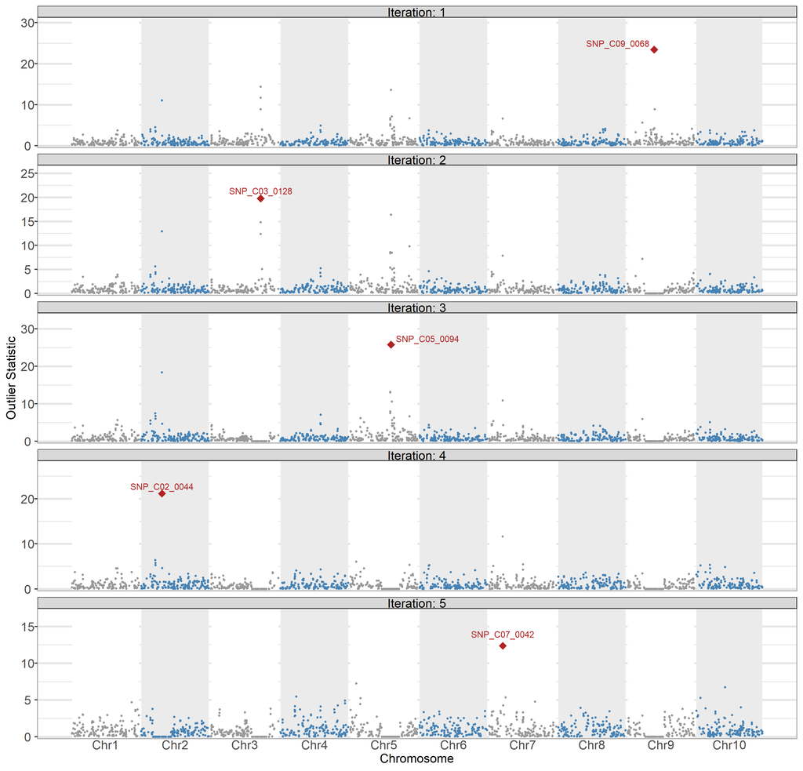

Manhattan plots across all forward-selection iterations. Each panel shows the multivariate quadratic-form outlier statistic $o_k = \tilde{\boldsymbol{q}}_k^\top \boldsymbol{G}_a^{-1} \tilde{\boldsymbol{q}}_k / \tilde{v}_k$; the significant marker for that iteration is highlighted and labelled.

```r
plot(gwas_mv, genObj = panel, type = "manhattan", sig.col = "firebrick")
```

### 7.2 Genome-wide outlier statistics — `type = "outlier"`

The outlier plot displays the same multivariate quadratic-form statistic as line traces faceted by iteration. Chromosomal regions that persistently carry signal show up as tall peaks across multiple iterations:

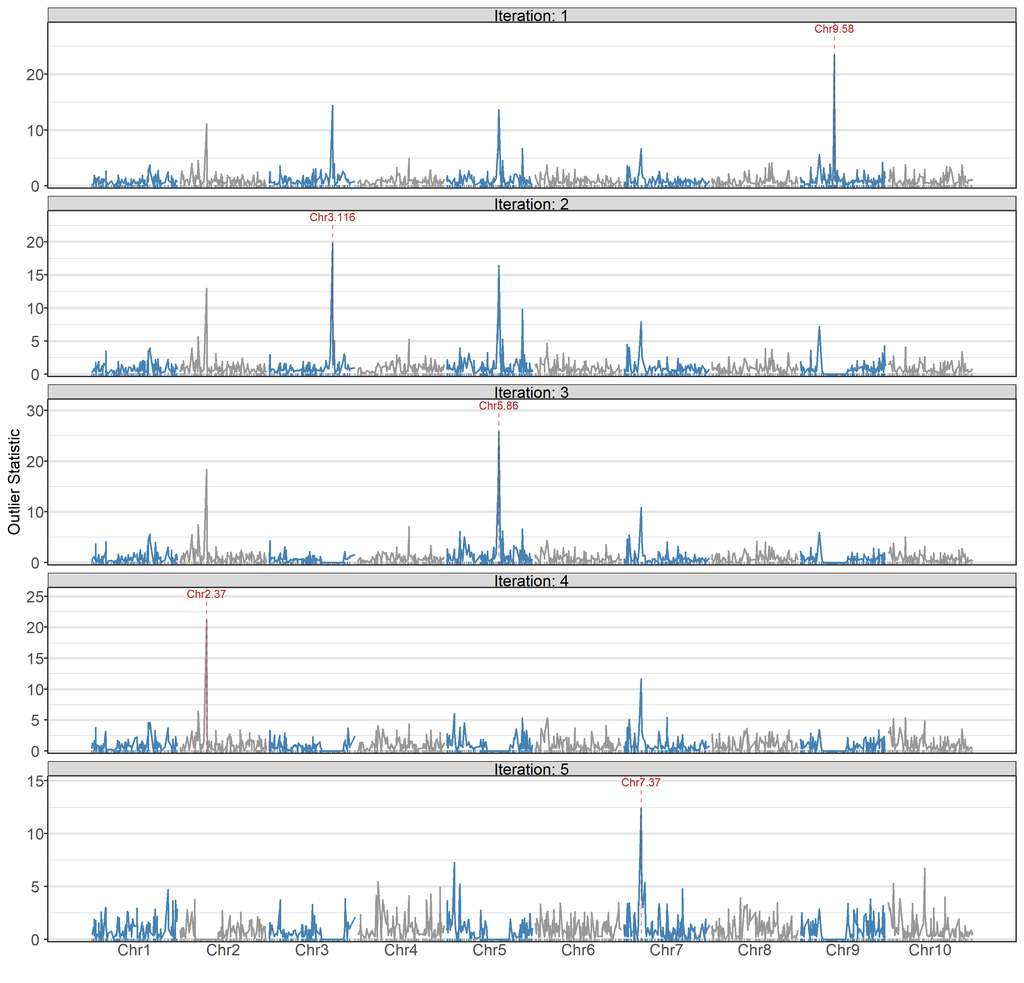

Line-plot view of the multivariate outlier statistic at each forward-selection iteration. Vertical dashed lines mark the selected marker in each iteration.

```r
plot(gwas_mv, genObj = panel, type = "outlier", sig.col = "firebrick")
```

### 7.3 Scaled genome-wide BLUPs — `type = "blups"`

For a multivariate GWAS object the BLUPs plot shows **one line per site**, coloured by site. This display is particularly informative: markers where all site lines move together indicate main-effect signal, while markers where site lines diverge or cross indicate G×E signal (in the raw scaled-BLUP domain, before the model has committed to MAIN vs INT classification):

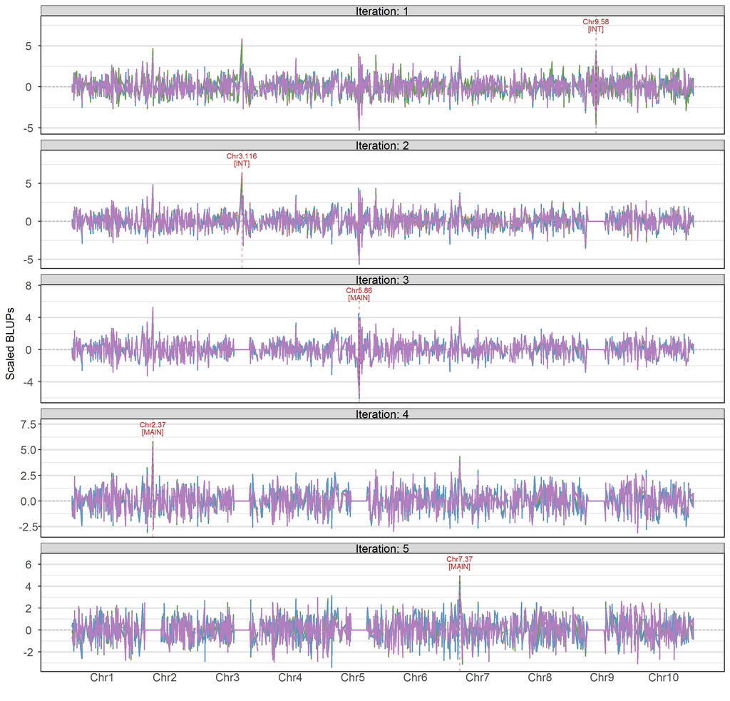

Scaled composite BLUPs across the genome at each iteration, one line per site. Convergent lines indicate consistent main-effect signal; divergent or crossing lines indicate G×E signal.

```r
plot(gwas_mv, genObj = panel, type = "blups", sig.col = "firebrick")
```

### 7.4 Allele effects — `type = "effects"`

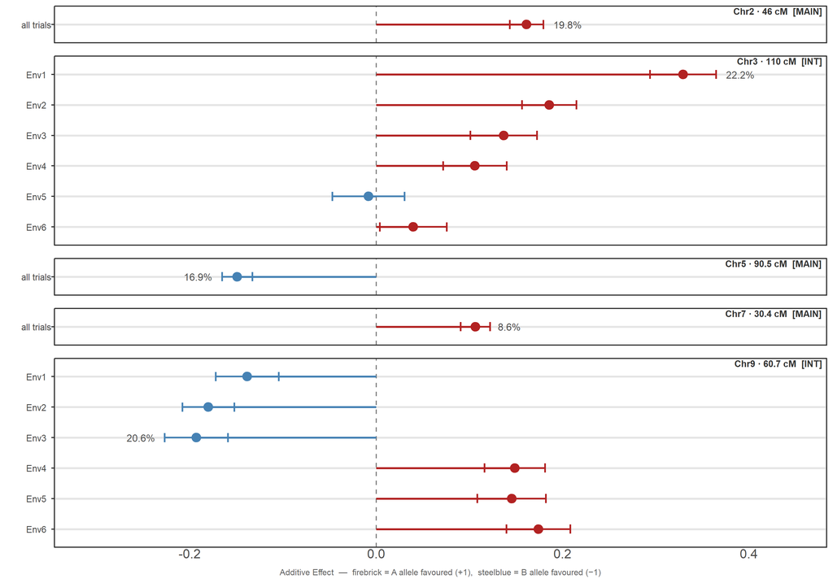

Per-site allele effects ± SE for each detected marker. Firebrick = +1 allele (raw genotype 2) favoured; steelblue = −1 allele (raw genotype 0) favoured. Main-effect markers show consistent colours across sites; G×E markers show site-dependent variation.

```r
plot(gwas_mv, genObj = panel, type = "effects")
```

### 7.5 Allele contrast — `type = "contrast"`

The contrast plot shows the total genetic value per line against its allele dosage class (0, 1, 2) at each detected marker, separately for each site. Main-effect markers show the same direction of separation across all site panels; G×E markers show the separation varying or reversing between site panels. As in the univariate vignette, this plot requires `data` — the augmented phenotype data frame that `gwasAim()` writes back to the calling environment as `yield.data`:

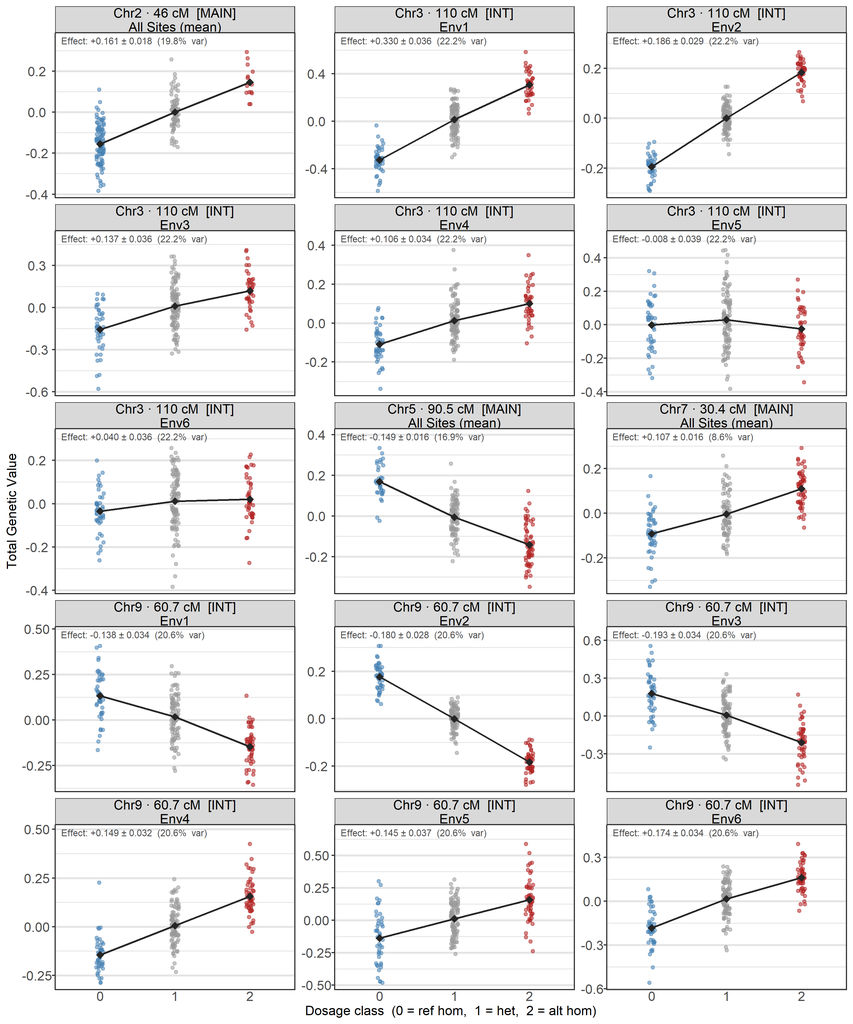

```r
plot(gwas_mv, genObj = panel, type = "contrast",
     data = yield.data, ncol = 3)
```

### 7.6 Iteration heatmap — `type = "heatmap"`

The heatmap gives a compact genome × iteration view, filling each cell with the multivariate outlier statistic. This makes it easy to see which chromosomal regions carried persistent multi-environment signal across iterations:

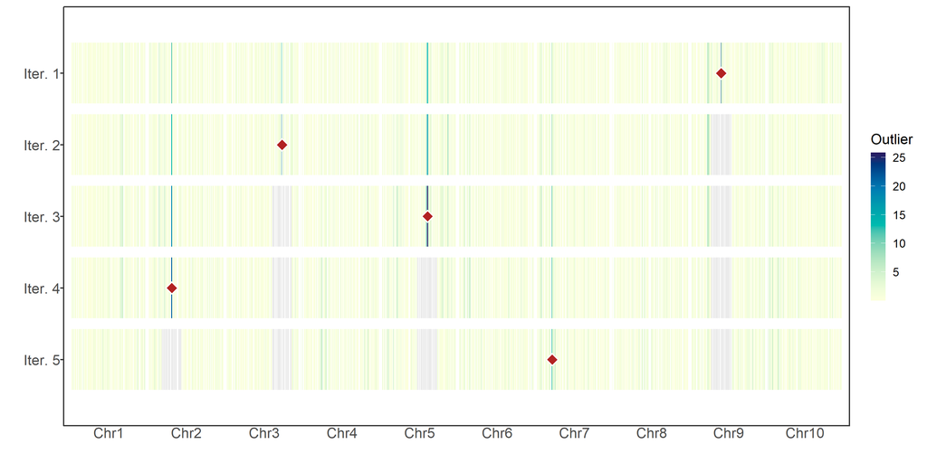

Iteration × genome heatmap of the multivariate outlier statistic. Detected markers are annotated.

```r
plot(gwas_mv, genObj = panel, type = "heatmap", sig.col = "firebrick")
```

### 7.7 Linkage map overlay — `linkMap()`

`linkMap()` overlays the detected markers on the panel map:

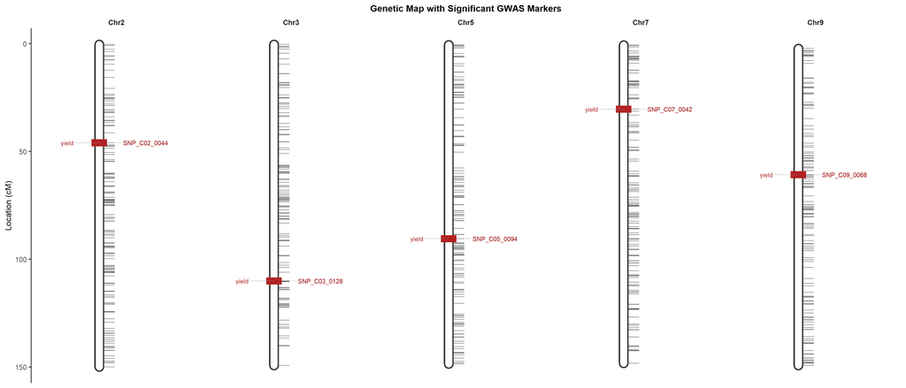

Genetic map with detected multi-environment GWAS markers overlaid. Marker names annotated on the right; the trait label on the left.

```r
linkMap(gwas_mv, genObj = panel, marker.names = "markers")
```

## 8 Iteration Diagnostics — `aimTrace()`

### 8.1 LRT trace — `plot = "lrt"`

The mixture chi-squared threshold (shown as a dashed line) reflects the $T$-dimensional nature of the test — it lies above the univariate $\chi^2_1$ threshold because the test jointly evaluates effects across all $T = 6$ sites:

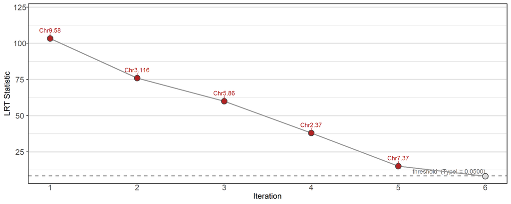

LRT statistic at each forward-selection iteration. The dashed line is the chi-squared mixture threshold at TypeI = 0.05 for T = 6 sites.

```r
aimTrace(gwas_mv, plot = "lrt", print.out = FALSE)
```

### 8.2 Effect stability — `plot = "stability"`

The stability plot traces the per-site allele effect ± 1 SE for each detected marker across iterations. Stable main-effect markers show all site lines tracking closely together; G×E markers show site lines that are separated or diverge as further markers enter the model. The panel is laid out with sites as rows and markers as columns, with a `[MAIN]` or `[INT]` tag in each column header:

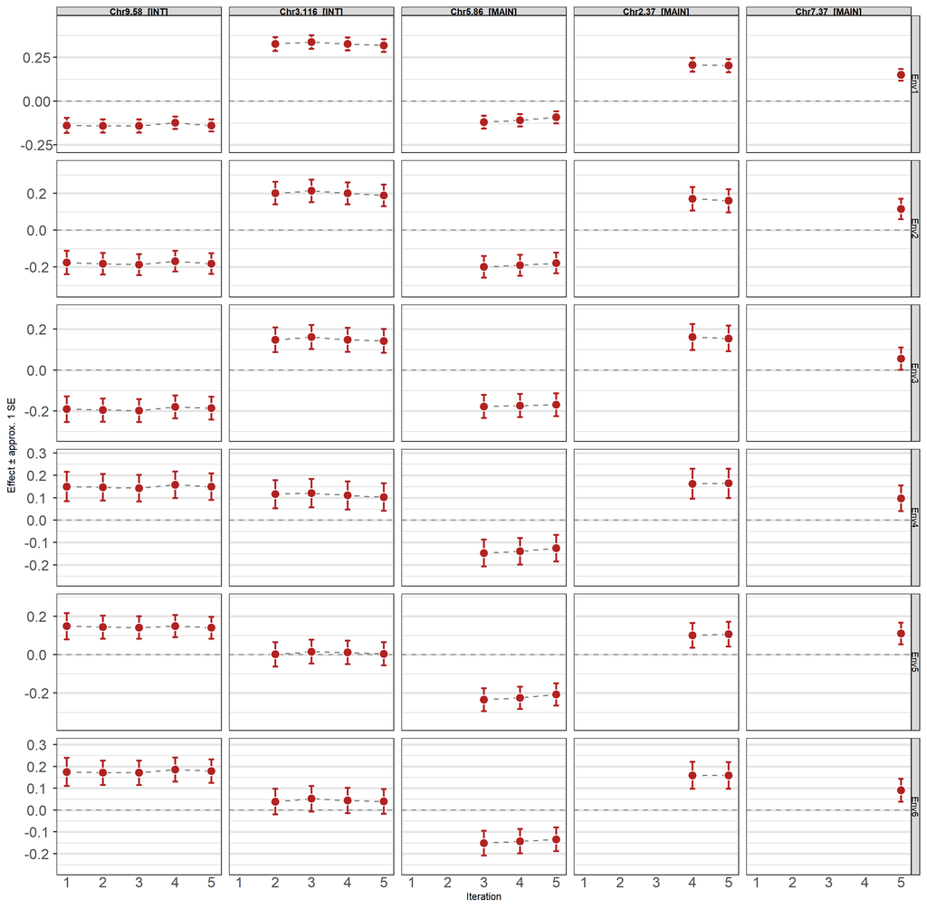

Per-site allele effect estimates ± 1 SE across iterations. Rows = sites; columns = detected markers with [MAIN] or [INT] suffix. Stable markers show consistent effects across iterations; G×E markers show site-dependent variation.

```r
aimTrace(gwas_mv, plot = "stability", print.out = FALSE)
```

## 9 Summary

The complete multi-environment GWAS pipeline illustrated in this vignette is:

```r
# 1. Pre-analysis: check -> filter -> prime the diversity panel
chk   <- checkPanel(genoGWASraw, mapGWASsim, id = "id")
flt   <- filterPanel(chk)
panel <- primePanel(flt, impute = "knn", knn.k = 5)

# 2. Phenotype setup
pheno       <- phenoGWASsim
pheno$id    <- factor(pheno$id)
pheno$Site  <- factor(pheno$Site)   # ensures Env1..Env6 ordering
pheno$Rep   <- factor(pheno$Rep)

# 3. Multi-trial base model progression (diag -> FA1 -> FA2)
base_diag <- asreml(yield ~ Site + Site:Rep,
                    random   = ~ diag(Site):id,
                    residual = ~ dsum(~units | Site),
                    data = pheno, na.action = na.method(x = "include"))
base_fa1  <- asreml(yield ~ Site + Site:Rep,
                    random   = ~ fa(Site, 1):id,
                    residual = ~ dsum(~units | Site),
                    data = pheno, na.action = na.method(x = "include"))
base_fa2  <- asreml(yield ~ Site + Site:Rep,
                    random   = ~ fa(Site, 2):id,
                    residual = ~ dsum(~units | Site),
                    data = pheno, na.action = na.method(x = "include"))

# 4. Multi-environment GWAS forward selection (str = NULL mirrors FA(2))
gwas_mv <- gwasAim(base_fa2, genObj = panel, merge.by = "id",
                   Trait = "Site", str = NULL,
                   TypeI = 0.05, exclusion.window = 20,
                   na.action = na.method(x = "include"), maxit = 100)

# 5. Results
summary(gwas_mv, genObj = panel)                 # MAIN/INT table by site
plot(gwas_mv,    genObj = panel)                 # Manhattan (default)
plot(gwas_mv,    genObj = panel, type = "outlier")
plot(gwas_mv,    genObj = panel, type = "blups")
plot(gwas_mv,    genObj = panel, type = "effects")
plot(gwas_mv,    genObj = panel, type = "contrast",
                 data = yield.data, ncol = 3)
plot(gwas_mv,    genObj = panel, type = "heatmap")
aimTrace(gwas_mv, plot = "lrt",       print.out = FALSE)
aimTrace(gwas_mv, plot = "stability", print.out = FALSE)
linkMap(gwas_mv,  genObj = panel)
```

## 10 References

Verbyla, A.P., Cullis, B.R. & Thompson, R. (2007). The analysis of QTL by simultaneous use of the full linkage map. *Theoretical and Applied Genetics*, **116**, 95–111. https://doi.org/10.1007/s00122-007-0676-4

Verbyla, A.P., Taylor, J.D. & Verbyla, K.L. (2012). RWGAIM: An efficient high-dimensional random whole genome average (QTL) interval mapping approach. *Genetics Research*, **94**, 291–306. https://doi.org/10.1017/S0016672312000493

Taylor, J. & Verbyla, A.P. (2011). R Package wgaim: QTL Analysis in Bi-Parental Populations Using Linear Mixed Models. *Journal of Statistical Software*, **40**(7), 1–18. https://doi.org/10.18637/jss.v040.i07

Smith, A.B., Cullis, B.R. & Thompson, R. (2001). Analyzing variety by environment data using multiplicative mixed models and adjustments for spatial field trend. *Biometrics*, **57**(4), 1138–1147. https://doi.org/10.1111/j.0006-341X.2001.01138.x

VanRaden, P.M. (2008). Efficient methods to compute genomic predictions. *Journal of Dairy Science*, **91**(11), 4414–4423. https://doi.org/10.3168/jds.2007-0980